# Income prediction: Banking

18 July 2019

## Problem

A bank offers different kind of bank deposits to their clients and want to classify them in order to recommend them a sort of deposit according to their needs

[figure not shown]

## Description dataset

Data has 48678 observations and 15 variables. The rows represent people who live California and the columns some characteristics of them like age. The last col Income tell us if individual gain more than 50k dollards per year.

| Age | Workclass | Fnlg | Education | Education_Num | Marital_status | Occupation | Relationship |
| --- | --- | --- | --- | --- | --- | --- | --- |
| 38 | Private | 89814 | HS-grad | 9 | Married | Farming-fishing | Husband |
| 55 | Private | 104996 | 7th-8th | 4 | Married | Craft-repair | Husband |
| 39 | Private | 290208 | 7th-8th | 4 | Married | Craft-repair | Husband |
| 54 | Private | 186272 | Some-college | 10 | Married | Transport-moving | Husband |

| Race | Gender | Capital_Gain | Capital_Loss | Hours_Per_Week | Native_Country | Income |
| --- | --- | --- | --- | --- | --- | --- |
| White | Male | 0 | 0 | 50 | United-States | <=50K |
| White | Male | 0 | 0 | 10 | United-States | <=50K |
| White | Male | 0 | 0 | 40 | Mexico | <=50K |
| White | Male | 3908 | 0 | 50 | United-States | <=50K |

# Data preproccesing

## Data preproccesing

> Missing values

> Outliers detection

> Data transformation

# Missing values

## Missing values

We remove rows with mising values, we have enough data

|  | x |
| --- | --- |
| Age | 0 |
| Workclass | 2799 |
| Fnlg | 0 |
| Education | 0 |
| Education_Num | 0 |
| Marital_status | 0 |
| Occupation | 2809 |
| Relationship | 0 |
| Race | 0 |
| Gender | 0 |
| Capital_Gain | 0 |
| Capital_Loss | 0 |
| Hours_Per_Week | 0 |
| Native_Country | 857 |
| Income | 0 |

# Outliers detection

## Outliers detection

We do not remove outliers because are relevant to the problem

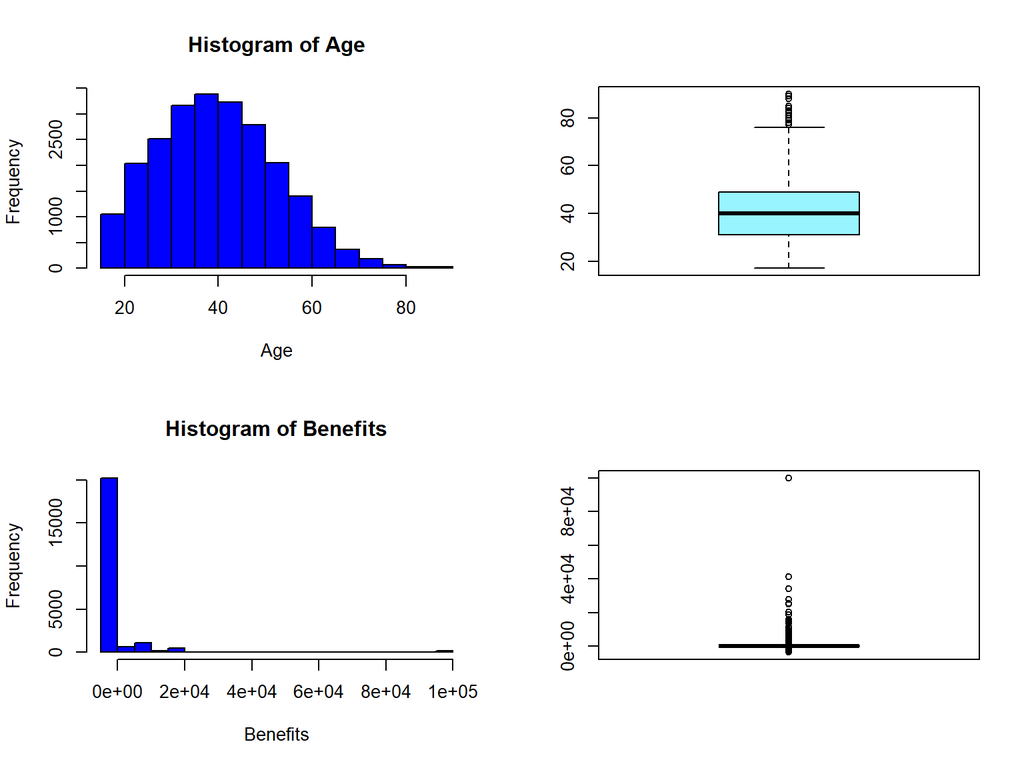

## Outliers detection

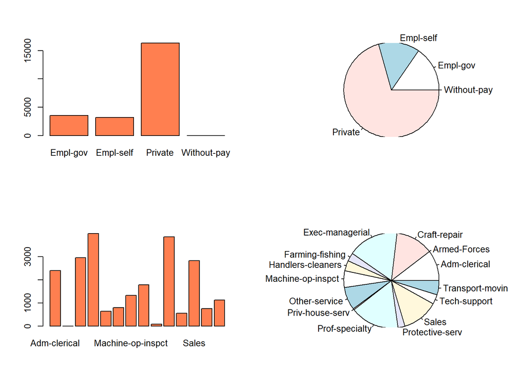

# Data transformation

## Data transformation

$${Benefits}={\small Capital Gain-CapitalLoss}$$

| Capital_Gain | Capital_Loss | Benefits |
| --- | --- | --- |
| 5013 | 0 | 5013 |
| 0 | 1628 | -1628 |
| 2463 | 0 | 2463 |
| 2885 | 0 | 2885 |
| 1471 | 0 | 1471 |
| 4064 | 0 | 4064 |
| 10566 | 0 | 10566 |
| 2463 | 0 | 2463 |
| 3137 | 0 | 3137 |

## Data transformation

We modify labels of categoric variable Marital_status

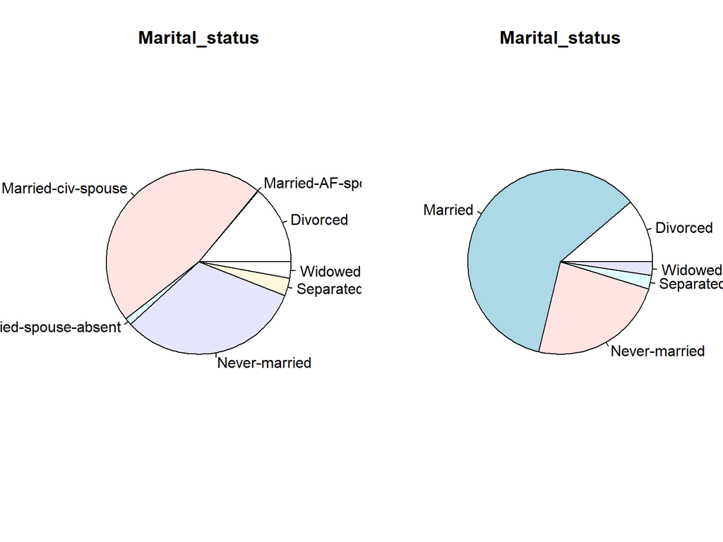

# Data visualization

## Questions

- **¿Does an individual gain more than 50000 dollars per year?**

## Questions

Does variable Marital_status serve us to predict Income?

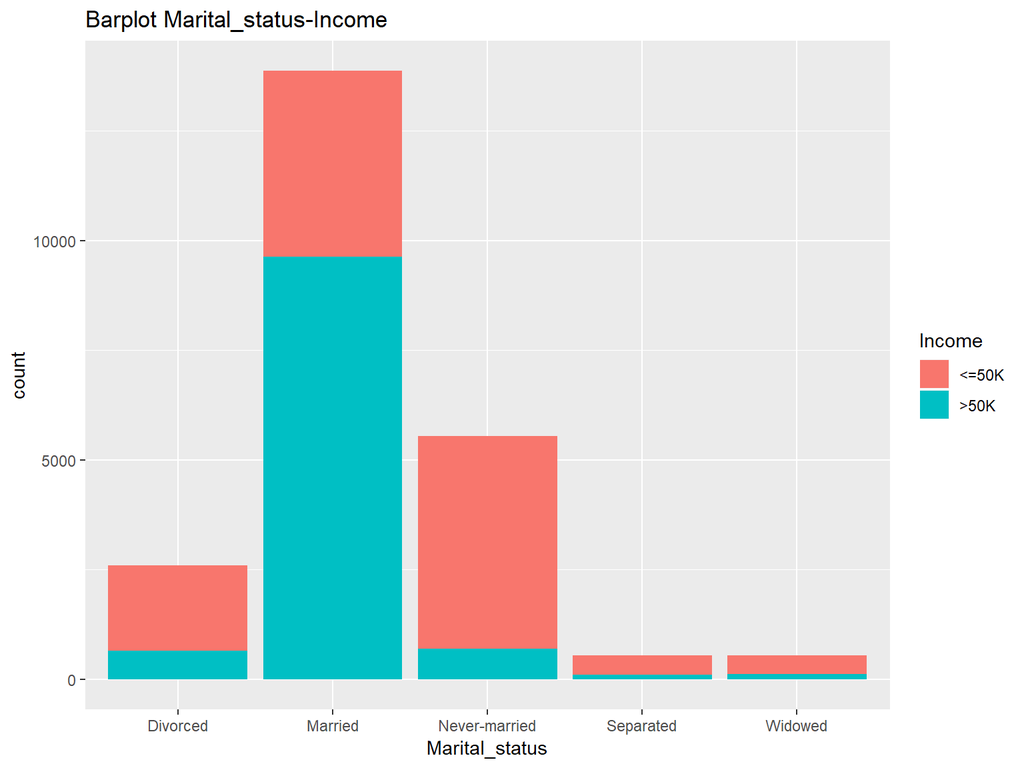

## Data visualization

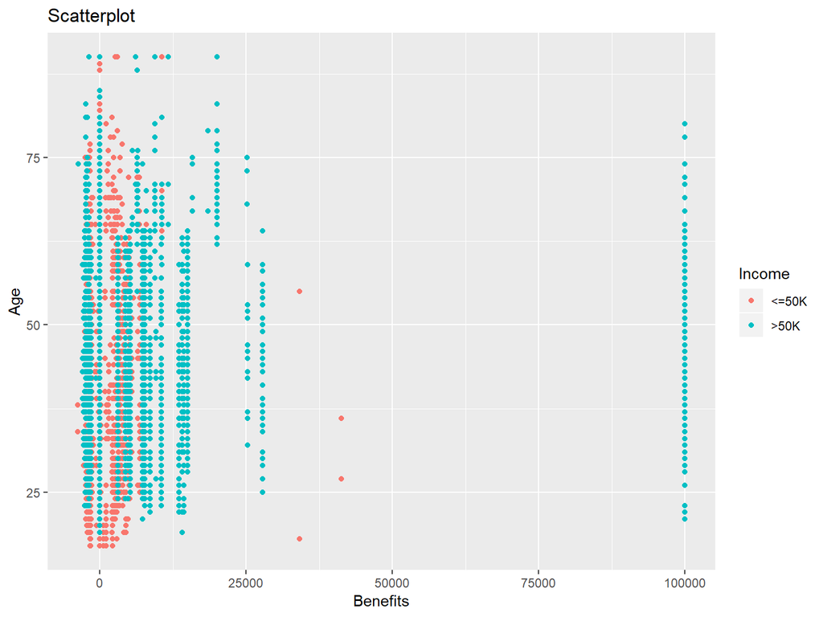

## Data visualization

- https://viro91.shinyapps.io/Visual_Data

# Analysis

## Prepare data

We balance proportion of observations labeled by target variable

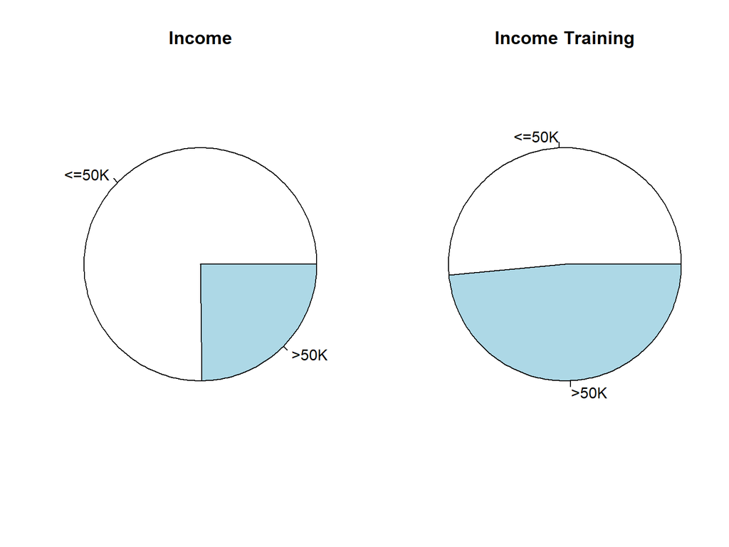

## Training and testing

We split data in 2 sets train and test

## Methods

Clasification techniques:

- Logistic Regression
- Linear and quadratic discriminant analysis
- K Nearest Neighboor

# Model selection

## Model selection

We apply stepwise selection using all variables.

$${ Income \sim .}$$

## Model selection

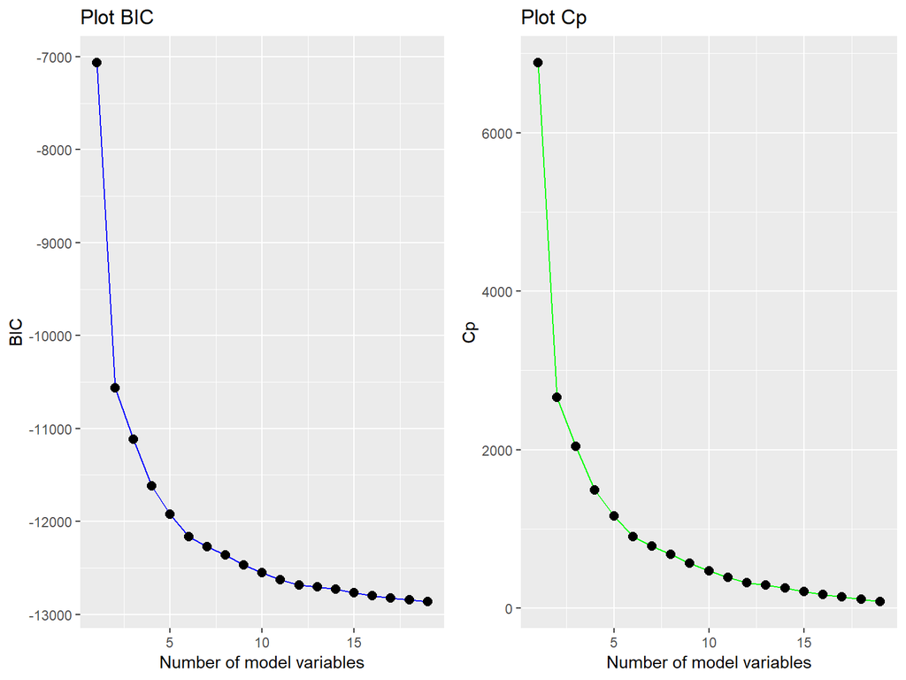

## Model selection

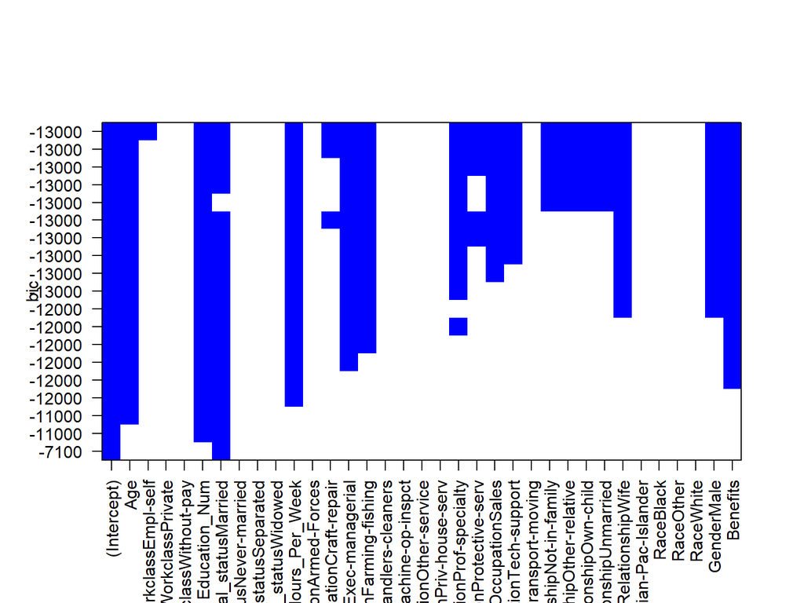

## Model selection

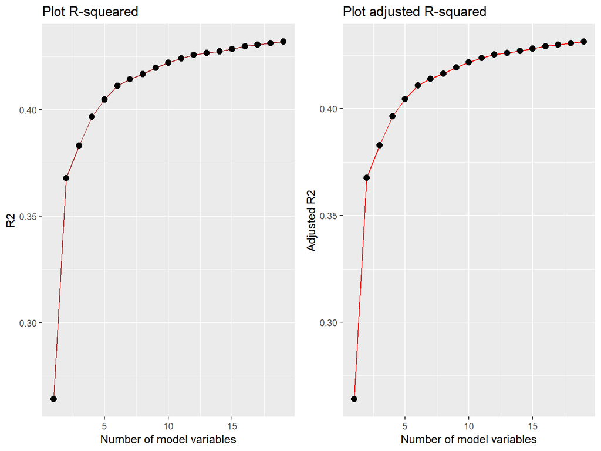

## Model selection:

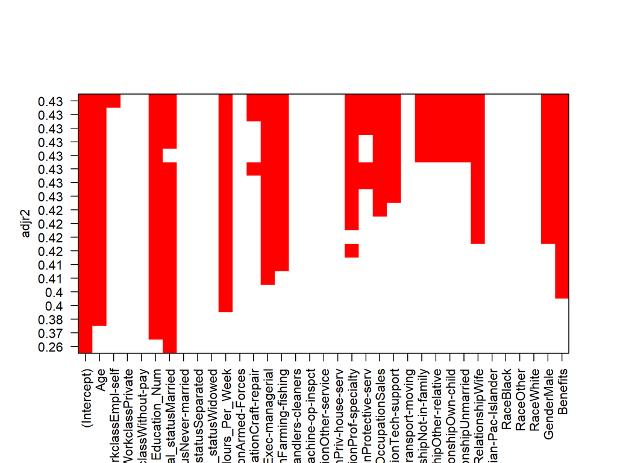

## Model selection

We decide use 5 variables to train our models because to add variables do not increase significantly accuracy of model

$${ Income \sim }{ \ Maritalstatus+Educationnum+Age+Hoursperweek+Benefits}$$

## Model selection:

# Logistic Regression

## Logistic Regression

$${Income \sim }{\small \ Maritalstatus+Educationnum+Age+Hoursperweek+Benefits}$$

Training confusion matrix and statistics

|  | <=50K | >50K |
| --- | --- | --- |
| <=50K | 6914 | 1500 |
| >50K | 2023 | 6903 |

|  | x |
| --- | --- |
| Accuracy | 0.7968281 |
| Sensitivity | 0.7736377 |
| Specificity | 0.8214923 |

## Logistic Regression

Coefficients and significativity of variables

|  | Estimate | Std..Error | z.value | Pr…z.. | Significativity |
| --- | --- | --- | --- | --- | --- |
| (Intercept) | -8.4336 | 0.1809 | -46.6099 | 0.0000 | TRUE |
| Education_Num | 0.3814 | 0.0094 | 40.3799 | 0.0000 | TRUE |
| Age | 0.0307 | 0.0019 | 16.1282 | 0.0000 | TRUE |
| Marital_statusMarried | 2.2055 | 0.0672 | 32.8278 | 0.0000 | TRUE |
| Marital_statusNever-married | -0.5346 | 0.0864 | -6.1907 | 0.0000 | TRUE |
| Marital_statusSeparated | -0.0559 | 0.1630 | -0.3430 | 0.7316 | FALSE |
| Marital_statusWidowed | -0.1425 | 0.1575 | -0.9052 | 0.3653 | FALSE |
| Hours_Per_Week | 0.0375 | 0.0019 | 19.3783 | 0.0000 | TRUE |
| Benefits | 0.0002 | 0.0000 | 22.8375 | 0.0000 | TRUE |

## Logistic Regression:

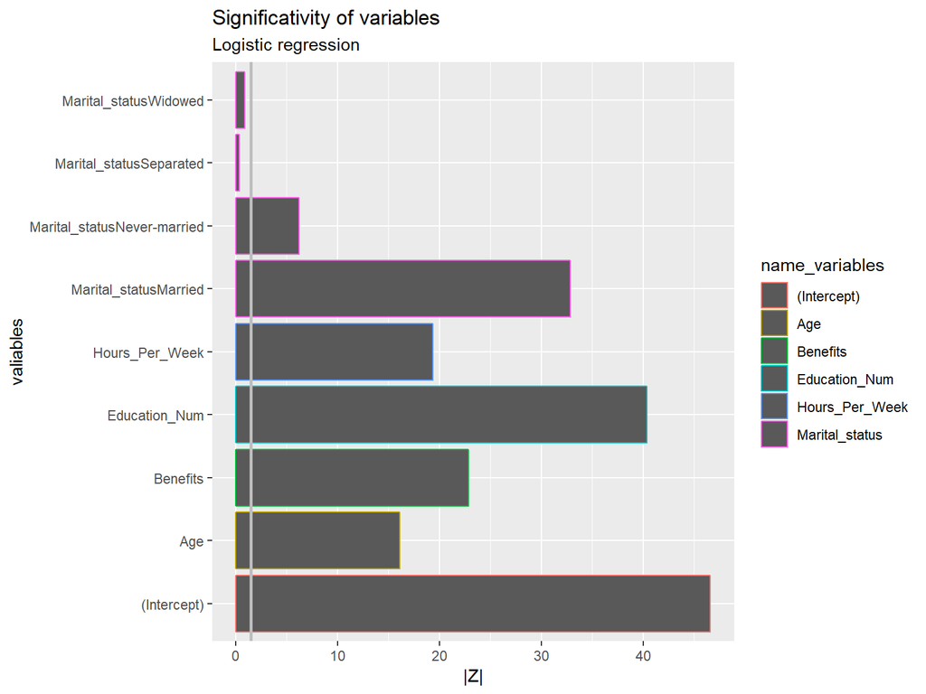

## Logistic Regression

Testing confusion matrix and statistics

|  | <=50K | >50K |
| --- | --- | --- |
| <=50K | 2324 | 486 |
| >50K | 636 | 2319 |

|  | x |
| --- | --- |
| Accuracy | 0.8053773 |
| Sensitivity | 0.7851351 |
| Specificity | 0.8267380 |

## Logistic Regression

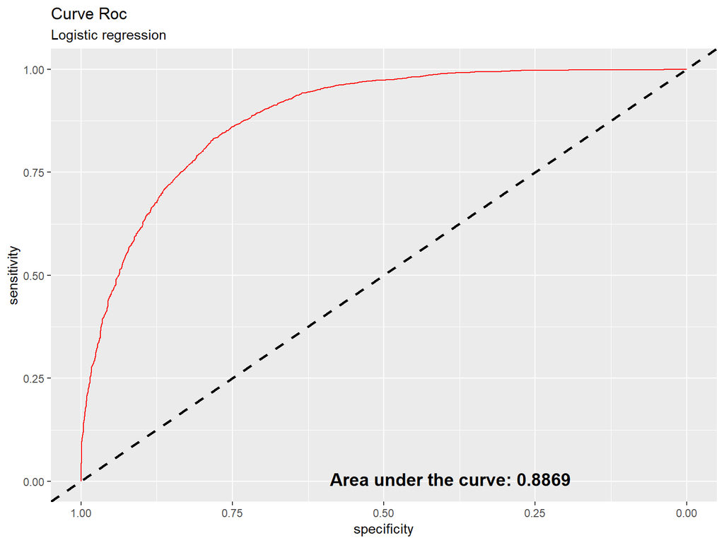

## Logistic Regression

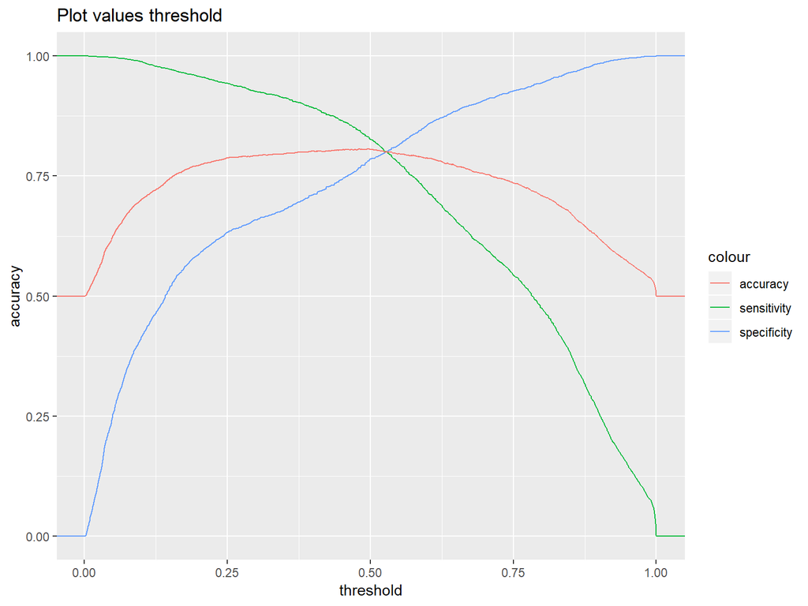

## Logistic Regression

| Accuracy | Sensitivity | Specificity | threshold |
| --- | --- | --- | --- |
| 0.7993062 | 0.7118243 | 0.8916221 | 0.4000000 |
| 0.8029488 | 0.7432432 | 0.8659537 | 0.4500000 |
| 0.8058977 | 0.7807432 | 0.8324421 | 0.4941281 |
| 0.8053773 | 0.7851351 | 0.8267380 | 0.5000000 |
| 0.8000000 | 0.8020270 | 0.7978610 | 0.5300000 |
| 0.7937554 | 0.8327703 | 0.7525847 | 0.5700000 |
| 0.7838682 | 0.8692568 | 0.6937611 | 0.6200000 |

## Logistic Regression

Comparisson models

| numb_variables | anova_logistic..Resid..Df. | anova_logistic..Resid..Dev. |
| --- | --- | --- |
| 1 | 17335 | 19008.36 |
| 2 | 17334 | 16450.97 |
| 3 | 17333 | 16160.01 |
| 4 | 17332 | 15710.69 |
| 5 | 17331 | 14711.31 |
| 6 | 17318 | 14210.83 |
| 7 | 17325 | 14453.68 |
| 8 | 17312 | 13971.81 |
| 9 | 17312 | 13971.81 |

# Discriminant analysis

## Linear discriminant analysis

Training confusion matrix and statistics

|  | <=50K | >50K |
| --- | --- | --- |
| <=50K | 6418 | 1204 |
| >50K | 2519 | 7199 |

|  | x |
| --- | --- |
| Accuracy | 0.7852941 |
| Sensitivity | 0.7181381 |
| Specificity | 0.8567178 |

## Linear discriminant analysis

Testing confusion matrix and statistics

|  | <=50K | >50K |
| --- | --- | --- |
| <=50K | 2161 | 386 |
| >50K | 799 | 2419 |

|  | x |
| --- | --- |
| Accuracy | 0.7944493 |
| Sensitivity | 0.7300676 |
| Specificity | 0.8623886 |

## Linear discriminant analysis

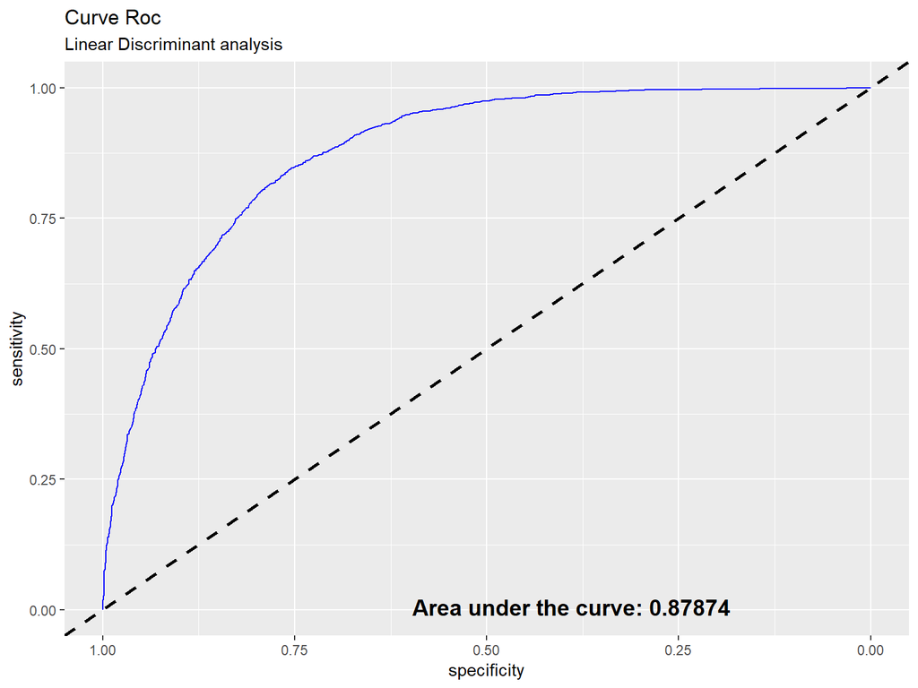

## Linear discriminant analysis

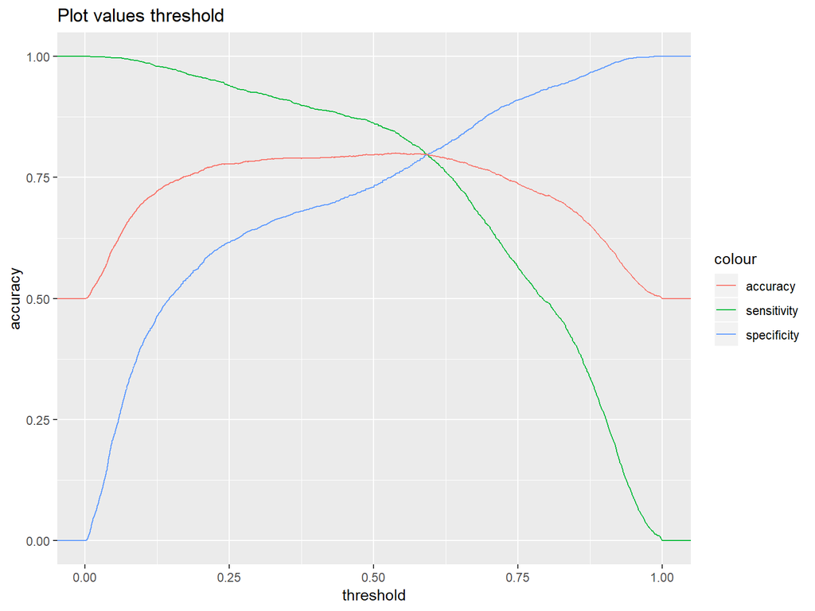

## Linear discriminant analysis

| Accuracy | Sensitivity | Specificity | threshold |
| --- | --- | --- | --- |
| 0.7875108 | 0.6891892 | 0.8912656 | 0.4000000 |
| 0.7908066 | 0.7084459 | 0.8777184 | 0.4500000 |
| 0.7944493 | 0.7300676 | 0.8623886 | 0.5000000 |
| 0.7994796 | 0.7577703 | 0.8434938 | 0.5375239 |
| 0.7980919 | 0.7797297 | 0.8174688 | 0.5700000 |
| 0.7921943 | 0.8135135 | 0.7696970 | 0.6200000 |

## Quadratic discriminant analysis

Training confusion matrix and statistics

|  | <=50K | >50K |
| --- | --- | --- |
| <=50K | 7488 | 2171 |
| >50K | 1449 | 6232 |

|  | x |
| --- | --- |
| Accuracy | 0.7912341 |
| Sensitivity | 0.8378651 |
| Specificity | 0.7416399 |

## Quadratic discriminant analysis

Testing confusion matrix and statistics

|  | <=50K | >50K |
| --- | --- | --- |
| <=50K | 2499 | 711 |
| >50K | 461 | 2094 |

|  | x |
| --- | --- |
| Accuracy | 0.7967042 |
| Sensitivity | 0.8442568 |
| Specificity | 0.7465241 |

## Quadratic discriminant analysis

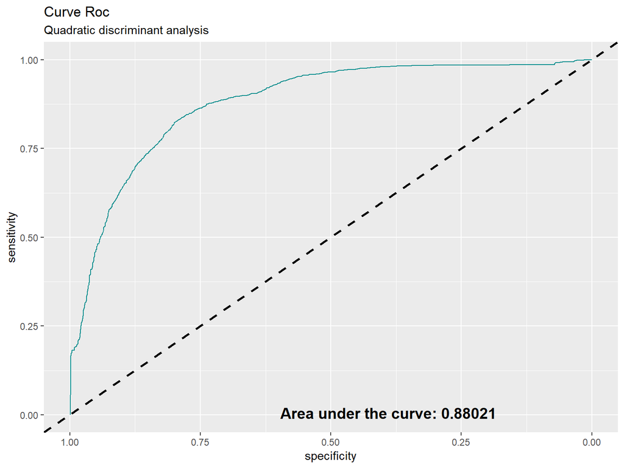

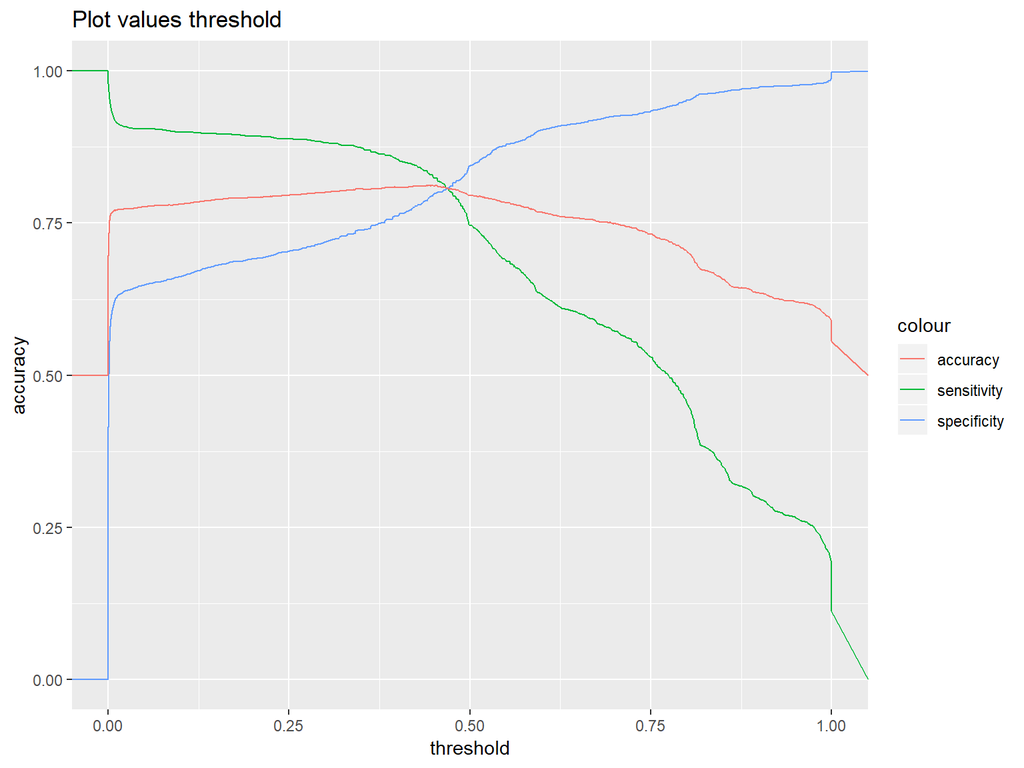

| Accuracy | Sensitivity | Specificity | threshold |
| --- | --- | --- | --- |
| 0.8069384 | 0.7618243 | 0.8545455 | 0.4000000 |
| 0.8116219 | 0.7996622 | 0.8242424 | 0.4546504 |
| 0.7967042 | 0.8442568 | 0.7465241 | 0.5000000 |
| 0.7934085 | 0.8574324 | 0.7258467 | 0.5200000 |
| 0.7809193 | 0.8847973 | 0.6713012 | 0.5700000 |
| 0.7660017 | 0.9084459 | 0.6156863 | 0.6200000 |

# K Nearest Neighboor

## K Nearest Neighboor

Training confusion matrix and statistics

|  | <=50K | >50K |
| --- | --- | --- |
| <=50K | 6992 | 1063 |
| >50K | 1945 | 7340 |

|  | x |
| --- | --- |
| Accuracy | 0.8265283 |
| Sensitivity | 0.7823654 |
| Specificity | 0.8734976 |

## K Nearest Neighboor

Testing confusion matrix and statistics

|  | <=50K | >50K |
| --- | --- | --- |
| <=50K | 2215 | 412 |
| >50K | 745 | 2393 |

|  | x |
| --- | --- |
| Accuracy | 0.7993062 |
| Sensitivity | 0.7483108 |
| Specificity | 0.8531194 |

## K Nearest Neighboor

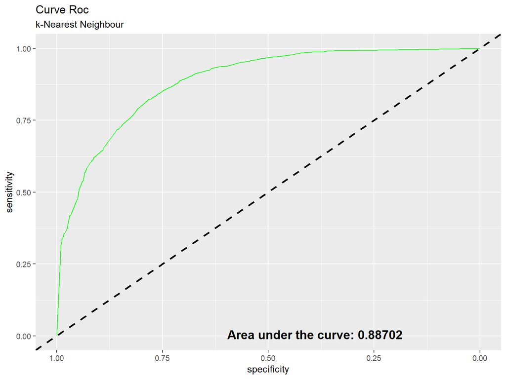

## K Nearest Neighboor

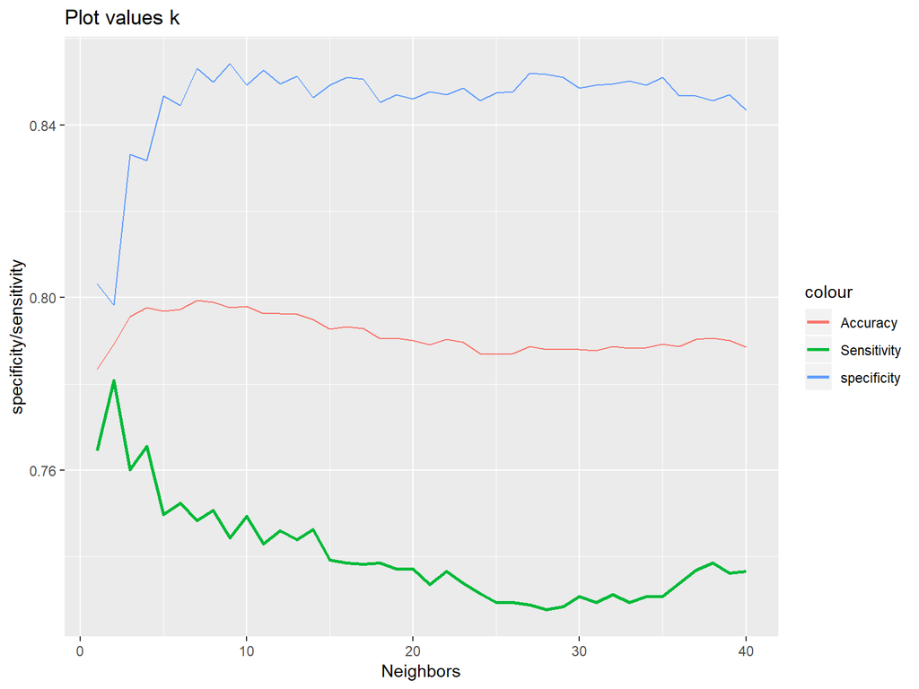

## K Nearest Neighboor

| Accuracy | Sensitivity | Specificity | Neighbors |
| --- | --- | --- | --- |
| 0.7833478 | 0.7645270 | 0.8032086 | 1 |
| 0.7892454 | 0.7807432 | 0.7982175 | 2 |
| 0.7956635 | 0.7601351 | 0.8331551 | 3 |
| 0.7977450 | 0.7655405 | 0.8317291 | 4 |
| 0.7968777 | 0.7496622 | 0.8467023 | 5 |
| 0.7972246 | 0.7523649 | 0.8445633 | 6 |
| 0.7993062 | 0.7483108 | 0.8531194 | 7 |
| 0.7989592 | 0.7506757 | 0.8499109 | 8 |
| 0.7977450 | 0.7442568 | 0.8541889 | 9 |
| 0.7979185 | 0.7493243 | 0.8491979 | 10 |
| 0.7963573 | 0.7429054 | 0.8527629 | 11 |
| 0.7963573 | 0.7459459 | 0.8495544 | 12 |
| 0.7961839 | 0.7439189 | 0.8513369 | 13 |
| 0.7949696 | 0.7462838 | 0.8463458 | 14 |
| 0.7927147 | 0.7391892 | 0.8491979 | 15 |
| 0.7932350 | 0.7385135 | 0.8509804 | 16 |
| 0.7928881 | 0.7381757 | 0.8506239 | 17 |
| 0.7904597 | 0.7385135 | 0.8452763 | 18 |
| 0.7906331 | 0.7371622 | 0.8470588 | 19 |
| 0.7901127 | 0.7371622 | 0.8459893 | 20 |

## K Nearest Neighboor

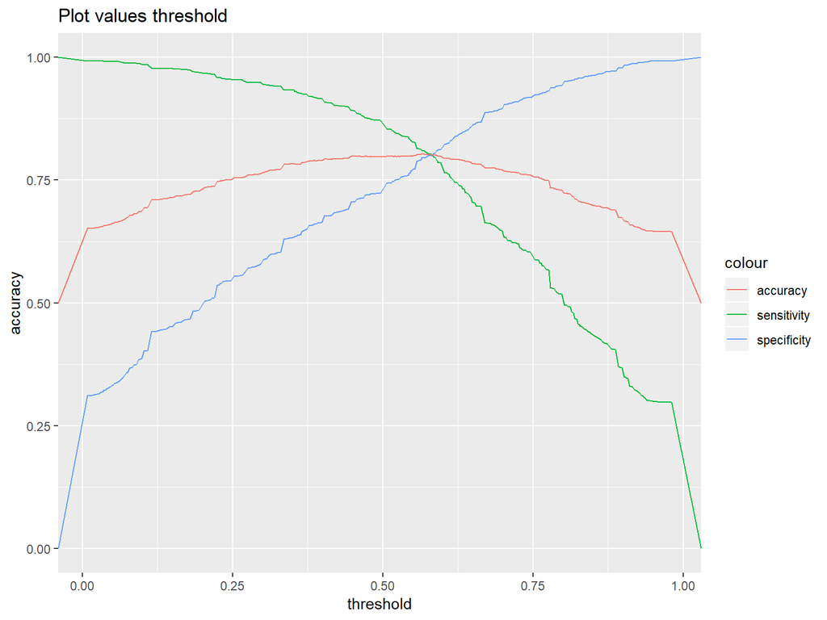

## K Nearest Neighboor

| Accuracy | Sensitivity | Specificity | threshold |
| --- | --- | --- | --- |
| 0.7897658 | 0.6766892 | 0.9090909 | 0.40000 |
| 0.7965308 | 0.7057432 | 0.8923351 | 0.45000 |
| 0.7977450 | 0.7442568 | 0.8541889 | 0.50000 |
| 0.8029488 | 0.7956081 | 0.8106952 | 0.56466 |
| 0.7935820 | 0.8391892 | 0.7454545 | 0.62000 |